# O Mercado do Profissional da Música e sua Formação

9 de setembro de 2016

## Motivações

A partir de um desafio proposta pela Pró-Reitoria Acadêmica do CEUNIH, investiguei o trabalho do profissional de música/educação musical baseado nas atividades que ele deve desenvolver no exercício de sua profissão e em sua inserção em diferentes organizações.

Para isso, primeiro foi necessário transcender o perfil do egresso atualmente traçado como **educador musical** para um profissional multifacetado com possibilidades de atuação em diferentes nichos de mercado. Esta nova concepção está ancorada, também, no perfil do aluno ingressante.

## O processo de investigação

Percebemos que, em geral, o aluno ingressante do curso de Música do CEUNIH já tem alguma experiência. Isso não é exclusividade nossa, mas uma característica inerente ao ensino superior de música.

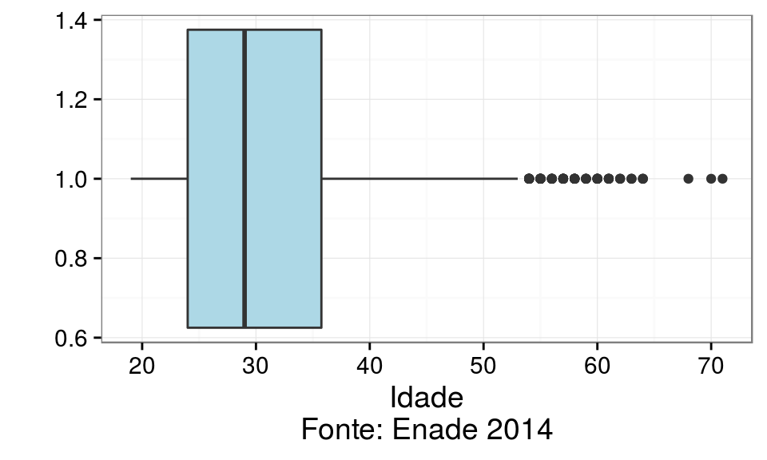

## O novo perfil do egresso.

Desse modo, consultei profissionais de sucesso que atuam no âmbito do ensino de música, da performance e do trabalho em estúdio. Além disso, foram consultadas as matrizes curriculares das principais faculdades de música no Brasil e algumas no exterior

Espera-se que um profissional da música possa atuar como:

- Educador Musical
- Performer
- Produtor Musical

## Competências

A partir disso, foram elencadas as seguintes competências:

- **Educação Musical**
- **Performance** Artística
- **Práticas Pedagógicas**
- Uso inovador de **Tecnologias**
- **Empreendedorismo**

## Competências no currículo

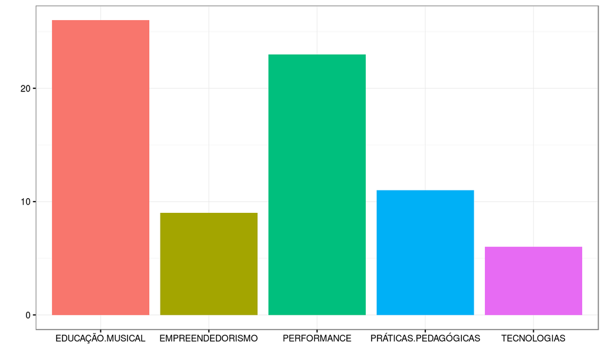

## EaD e Internacionalização

Visando transcender o alcance de nosso ensino de música, disciplinas em EaD estão sendo planejadas com professores em outros locais do Brasil e do exterior. Além de possibilitar ao aluno a experiência transcultural, essa prática abre a possibilidade de intercâmbios e experiências profissionais. O foco das disciplinas reside nos seguintes tópicos:

- "Ações empreendedoras e novos nichos de mercado" (Hastings - England)
- "Programação para produção musical em Pure Data - Pd" (São Paulo)

## Obrigado.

Dúvidas? Sugestões?